# DAG Analysis: Weather × Post-MoU Mortality Model

Author

Giorgio Coppola

Published

March 25, 2026

## Research question

Did the 2017 EU-Libya MoU make the Central Mediterranean route more dangerous (increase per-crossing mortality)?

**Identification strategy:** Weather × Post-MoU interaction ($\beta_3$) captures how the MoU changed the Weather → vulnerability → Deaths pathway.

## 1. Define the DAG

Nodes and edges traced from `dag-1.pdf`:

| Node | Description | Status |
| --- | --- | --- |
| MoU | Feb 2017 EU-Libya policy shock | Exposure (treatment) |
| Deaths | Death count (per incident or aggregate) | Outcome |
| Vulnerability | Crossing vulnerability (boat quality, rescue, conditions, overcrowding) | **Latent (unobservable)** |
| Weather | Sea conditions: SWH, wind, SST | Observed, exogenous |
| FE | Seasonality + grid fixed effects | Adjusted (in model) |
| SAR | Search & rescue capacity | Mostly unobserved (low quality data) |
| Boats | Vessel type/quality | Partially observed |
| Crossings | Crossing volume | Observed, endogenous |

```r
library(dagitty)

dag <- dagitty('
dag {
  MoU       [exposure, pos="4,-0.5"]
  Deaths    [outcome,  pos="6.5,2"]
  Vulnerability      [latent,   pos="4,2"]
  Weather   [pos="0,2"]
  FE        [adjusted, pos="1.5,3.5"]
  SAR       [pos="3,0.5"]
  Boats     [pos="5,0.5"]
  Crossings [pos="1.5,1.1"]

  MoU -> SAR
  MoU -> Boats
  MoU -> Crossings
  SAR -> Crossings
  SAR -> Vulnerability
  Boats -> Crossings
  Boats -> Vulnerability
  Weather -> Crossings
  Weather -> Vulnerability
  Vulnerability -> Deaths
  Crossings -> Deaths
  FE -> Weather
  FE -> Crossings
  FE -> Vulnerability
  FE -> Deaths
}
')
```

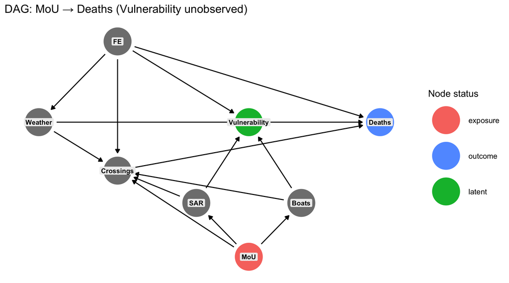

```r
library(ggdag)
library(ggplot2)

ggdag_status(dag, text = FALSE) +
  geom_label(aes(label = name),
             fill = "grey93", colour = "black",
             size = 3, fontface = "bold",
             label.padding = unit(0.2, "lines"),
             label.size = 0, na.rm = TRUE) +
  theme_dag() +
  guides(color = guide_legend(title = "Node status")) +
  ggtitle("DAG: MoU → Deaths (Vulnerability unobserved)")
```

**NoteNotes on edge directionality and omitted edges**

**SAR ↔︎ Crossings (bidirectional in theory, unidirectional in the DAG).** The DAG includes SAR → Crossings, representing the post-MoU deterrence channel: reduced SAR capacity reduces crossings (Rodriguez Sanchez et al. 2023, Model C; Hoffmann Pham & Komiyama 2024, ECM). However, the reverse — Crossings → SAR — is also plausible, especially in the pre-MoU period: the migration crisis drove the expansion of SAR operations (Mare Nostrum was launched in response to the October 2013 Lampedusa shipwreck; NGO SAR expanded as crossings surged). Rodriguez Sanchez et al. (2023) are explicit that SAR is partly a consequence of crossing attempts, not just a cause. In the post-MoU period that our model targets, the dominant direction is SAR → Crossings (policy-driven SAR withdrawal reduces crossings). The DAG represents this post-treatment causal direction.

**MoU → Crossings (direct deterrence channel).** The MoU reduced crossings not only through SAR withdrawal but also through direct deterrence mechanisms outside the SAR/Boats pathway: tightening of Libya’s southern border, detention of migrants in Libya, and signaling effects that discouraged departure (Zambiasi & Albarosa 2025). This edge is included in the DAG for completeness. Since MoU has no parents, it does not create backdoor paths.

**SAR → Boats (not included).** Deiana et al. (2024) show that extensive SAR *enables* inflatable boat use — their entire identification rests on SAR making unsafe boats viable. This suggests SAR → Boats may exist as a causal edge. We do not include it in the main DAG because (a) the MoU independently affected both SAR and Boats through distinct policy channels (SAR externalization vs. smuggler market disruption), and (b) adding SAR → Boats would not change identification (all paths remain front-door from MoU, which is parentless). However, the mechanism is real and should be acknowledged: part of the boat-type shift documented by Deiana et al. and Hoffmann Pham & Komiyama (2024) is mediated by SAR availability rather than being a direct MoU effect.

**MoU → Vulnerability directly (not included).** The MoU shifted migrants to more dangerous conditions in Libyan detention and exploitation (documented by Zambiasi & Albarosa 2025). If pre-crossing vulnerability feeds into at-sea crossing vulnerability, a direct MoU → Vulnerability edge could exist. We omit it from the main DAG because (a) Vulnerability as defined here captures *at-sea crossing vulnerability* specifically, not pre-departure conditions, and (b) even if included, it would not threaten identification since MoU has no parents. This channel is relevant for the broader discussion of MoU consequences but is outside the scope of the Weather × Post identification strategy.

**ImportantDetection and sample selection**

The DAG models the data generating process for **all** incidents on the CMR. However, IOM MMP records only incidents where at least one person died or went missing ($n = 1{,}388$ CMR incidents; every record has dead + missing $\geq 1$). The data also records survivors when known (577/1,388 incidents).

**Incident-formation selection.** Distress events where SAR rescued everyone (0 dead, 0 missing) do not appear in MMP. This is inherent to the data source. Pre-MoU, when SAR capacity was high, incidents still recorded deaths alongside many survivors (mean survivors = 243.7 pre-MoU vs. 61.1 post-MoU, among incidents with recorded survivors), indicating that SAR responded but could not prevent all fatalities. The pre-MoU weather–mortality gradient is estimated from this variation in severity across weather conditions. The key question is whether fully-rescued events (0 dead, 0 missing) are disproportionately concentrated in bad weather pre-MoU — if so, the pre-MoU gradient is attenuated. This is difficult to assess directly but is partially addressed by the weather common support diagnostic (`estimands.qmd` Section 2.3).

**Detection selection (genuine threat).** Post-MoU, the detection environment changed: NGO SAR vessels — which witnessed and reported many incidents — were restricted (Cusumano & Villa 2019), and the Libyan Coast Guard does not systematically report interceptions-gone-wrong. If detection probability changed differentially with weather post-MoU (e.g., NGO vessels that operated disproportionately in bad weather withdrew), the observed Weather × Post interaction conflates true danger amplification with detection-driven composition change.

Detection bias is not modeled in the DAG because it operates on the *observation process*, not on the causal data generating process for outcomes. It is addressed by the parameterized sensitivity analysis in `estimands.qmd` Section 3.6, Exercise 3, which models detection probability as a function of weather and period, and asks how much detection must have worsened to nullify the result.

## 2. All causal paths

### MoU → Deaths

```r
p_mou <- paths(dag, from = "MoU", to = "Deaths")
data.frame(
  status = ifelse(p_mou$open, "OPEN", "closed"),
  path   = p_mou$paths
)
```

```
   status
1    OPEN
2  closed
3  closed
4  closed
5  closed
6  closed
7  closed
8  closed
9  closed
10 closed
11 closed
12   OPEN
13 closed
14 closed
```

[output cut: 103 more lines]

### Weather → Deaths

```r
p_wx <- paths(dag, from = "Weather", to = "Deaths")
data.frame(
  status = ifelse(p_wx$open, "OPEN", "closed"),
  path   = p_wx$paths
)
```

```
   status
1    OPEN
2  closed
3  closed
4  closed
5  closed
6  closed
7  closed
8  closed
9  closed
10 closed
11 closed
12 closed
13 closed
14 closed
```

[output cut: 77 more lines]

## 3. Adjustment sets

### Total effect: MoU → Deaths

```r
adj_mou <- adjustmentSets(dag, exposure = "MoU", outcome = "Deaths",
                           type = "minimal")
if (length(adj_mou) == 0) {
  cat("No adjustment needed — no backdoor paths from MoU to Deaths.\n")
  cat("MoU is exogenous: it has no parents in the DAG.")
} else {
  print(adj_mou)
}
```

[output not shown]

### Total effect: Weather → Deaths

```r
adjustmentSets(dag, exposure = "Weather", outcome = "Deaths",
               type = "minimal")
```

```
{ FE }
```

Must condition on **FE** to block the backdoor: Deaths ← FE → Weather.

### Canonical adjustment sets

```r
cat("MoU → Deaths:\n")
```

```
MoU → Deaths:
```

```r
print(adjustmentSets(dag, exposure = "MoU", outcome = "Deaths",
                      type = "canonical"))
```

```
{ FE, Weather }
```

```r
cat("\nWeather → Deaths:\n")
```

```
Weather → Deaths:
```

```r
print(adjustmentSets(dag, exposure = "Weather", outcome = "Deaths",
                      type = "canonical"))
```

```
{ Boats, FE, MoU, SAR }
```

## 4. Checking specific conditioning strategies

```r
results <- data.frame(
  estimand = c(rep("MoU → Deaths", 3), rep("Weather → Deaths", 3)),
  conditioning_set = c(
    "{FE}", "{FE, Weather}", "{} (empty)",
    "{FE}", "{FE, MoU}", "{} (empty)"
  ),
  valid = c(
    isAdjustmentSet(dag, "MoU", "Deaths", c("FE")),
    isAdjustmentSet(dag, "MoU", "Deaths", c("FE", "Weather")),
    isAdjustmentSet(dag, "MoU", "Deaths", c()),
    isAdjustmentSet(dag, "Weather", "Deaths", c("FE")),
    isAdjustmentSet(dag, "Weather", "Deaths", c("FE", "MoU")),
    isAdjustmentSet(dag, "Weather", "Deaths", c())
  )
)
knitr::kable(results)
```

[output not shown]

**Note**

For the Weather × Post interaction model:

- The model conditions on **month FE** (= FE node) ✓
- Weather is exogenous to the MoU ✓
- The interaction $\beta_3$ captures the **change** in Weather’s total effect on Deaths across periods

## 5. Collider bias: conditioning on Crossings (Kronmal problem)

This is the DAG representation of **Kronmal (1993)**. When we use mortality **rate** = Deaths/Crossings as the outcome, we implicitly condition on Crossings.

Crossings is a **collider** between multiple parent nodes:

- Weather → Crossings ← SAR
- Weather → Crossings ← Boats

Conditioning on a collider **opens** spurious non-causal paths.

```r
cat("Is {FE, Crossings} valid for Weather → Deaths?\n")
```

```
Is {FE, Crossings} valid for Weather → Deaths?
```

```r
cat(isAdjustmentSet(dag, "Weather", "Deaths", c("FE", "Crossings")))
```

```
FALSE
```

### What paths open when we condition on Crossings?

```r
dag_cond_cross <- dag
adjustedNodes(dag_cond_cross) <- c("FE", "Crossings")
p_cond <- paths(dag_cond_cross, from = "Weather", to = "Deaths")
data.frame(
  status = ifelse(p_cond$open, "OPEN", "closed"),
  path   = p_cond$paths
)
```

```
   status
1    OPEN
2  closed
3  closed
4  closed
5  closed
6  closed
7  closed
8  closed
9  closed
10 closed
11 closed
12 closed
13 closed
14 closed
```

[output cut: 77 more lines]

**Warning**

**Kronmal problem in DAG terms:** conditioning on Crossings opens collider paths through SAR and Boats:

- Weather → [Crossings] ← SAR → Vulnerability → Deaths
- Weather → [Crossings] ← Boats → Vulnerability → Deaths

The mortality **rate** inherits denominator-driven bias because Crossings sits as a collider between Weather and SAR/Boats, which also causally affect Deaths through Vulnerability.

## 6. Can we fix collider bias by also conditioning on SAR + Boats?

```r
cat("Is {FE, Crossings, SAR, Boats} valid for Weather → Deaths?\n")
```

```
Is {FE, Crossings, SAR, Boats} valid for Weather → Deaths?
```

```r
cat(isAdjustmentSet(dag, "Weather", "Deaths",
                    c("FE", "Crossings", "SAR", "Boats")))
```

```
FALSE
```

```r
dag_cond_fix <- dag
adjustedNodes(dag_cond_fix) <- c("FE", "Crossings", "SAR", "Boats")
p_fix <- paths(dag_cond_fix, from = "Weather", to = "Deaths")
data.frame(
  status = ifelse(p_fix$open, "OPEN", "closed"),
  path   = p_fix$paths
)
```

```
   status
1    OPEN
2  closed
3  closed
4  closed
5  closed
6  closed
7  closed
8  closed
9  closed
10 closed
11 closed
12 closed
13 closed
14 closed
```

[output cut: 77 more lines]

**Note**

If SAR and Boats were fully observed, conditioning on {FE, Crossings, SAR, Boats} would block the collider paths and allow using the mortality rate. But SAR and Boats are only **partially observed** (and Vulnerability remains latent), so this fix is not practically available.

## 7. Implied conditional independencies

These are **testable** predictions of the DAG. If any of these fail empirically, the DAG structure may be wrong.

```r
ci <- impliedConditionalIndependencies(dag)
for (s in ci) cat(format(s), "\n")
```

```
Boats FE NULL
Boats SAR MoU
Boats Weather NULL
Deaths MoU Boats    , Crossings, FE       , SAR      , Weather
FE MoU NULL
FE SAR NULL
MoU Weather NULL
SAR Weather NULL
```

## 8. Instrumental variables

```r
cat("For MoU → Deaths:\n")
```

```
For MoU → Deaths:
```

```r
iv_mou <- instrumentalVariables(dag, exposure = "MoU", outcome = "Deaths")
if (length(iv_mou) == 0) {
  cat("  None needed (MoU is exogenous, no backdoor paths)\n")
} else {
  print(iv_mou)
}
```

```
  None needed (MoU is exogenous, no backdoor paths)
```

```r
cat("\nFor Weather → Deaths:\n")
```

```
For Weather → Deaths:
```

```r
iv_wx <- instrumentalVariables(dag, exposure = "Weather",
                                outcome = "Deaths")
if (length(iv_wx) == 0) {
  cat("  None found\n")
} else {
  print(iv_wx)
}
```

```
  None found
```

## 9. Sensitivity: adding Crossings → Vulnerability

Overcrowding from high volume could increase vulnerability. This adds a new causal chain: Weather → Crossings → Vulnerability → Deaths. Since FE → SAR and FE → Boats are absorbed by conditioning on FE, we only test this edge.

```r
dag_ext <- dagitty('
dag {
  MoU       [exposure, pos="4.5,-0.5"]
  Deaths    [outcome,  pos="6.5,2"]
  Vulnerability      [latent,   pos="4,2"]
  Weather   [pos="0,2"]
  FE        [adjusted, pos="2.5,4"]
  SAR       [pos="2.5,0.5"]
  Boats     [pos="5,0.5"]
  Crossings [pos="0.5,3"]

  MoU -> SAR
  MoU -> Boats
  MoU -> Crossings
  SAR -> Crossings
  SAR -> Vulnerability
  Boats -> Crossings
  Boats -> Vulnerability
  Weather -> Crossings
  Weather -> Vulnerability
  Vulnerability -> Deaths
  Crossings -> Deaths
  Crossings -> Vulnerability
  FE -> Weather
  FE -> Crossings
  FE -> Vulnerability
  FE -> Deaths
}
')

cat("With Crossings → Vulnerability added:\n\n")
```

```
With Crossings → Vulnerability added:
```

```r
cat("Adjustment sets for Weather → Deaths:\n")
```

```
Adjustment sets for Weather → Deaths:
```

```r
print(adjustmentSets(dag_ext, exposure = "Weather", outcome = "Deaths",
                      type = "minimal"))
```

```
{ FE }
```

```r
cat("\nAdjustment sets for MoU → Deaths:\n")
```

```
Adjustment sets for MoU → Deaths:
```

```r
adj_ext <- adjustmentSets(dag_ext, exposure = "MoU", outcome = "Deaths",
                           type = "minimal")
if (length(adj_ext) == 0) {
  cat("  Still no adjustment needed (MoU still exogenous)\n")
} else {
  print(adj_ext)
}
```

[output not shown]

```r
cat("Is {FE, Crossings} still invalid for Weather → Deaths?\n")
```

```
Is {FE, Crossings} still invalid for Weather → Deaths?
```

```r
cat(isAdjustmentSet(dag_ext, "Weather", "Deaths", c("FE", "Crossings")))
```

```
FALSE
```

```r
cat("\n\nPaths Weather → Deaths | {FE, Crossings} (extended DAG):\n")
```

```
Paths Weather → Deaths | {FE, Crossings} (extended DAG):
```

```r
dag_ext_cond <- dag_ext
adjustedNodes(dag_ext_cond) <- c("FE", "Crossings")
p_ext <- paths(dag_ext_cond, from = "Weather", to = "Deaths")
data.frame(
  status = ifelse(p_ext$open, "OPEN", "closed"),
  path   = p_ext$paths
)
```

```
   status
1    OPEN
2    OPEN
3  closed
4  closed
5  closed
6  closed
7  closed
8  closed
9  closed
10 closed
11 closed
12 closed
13 closed
14 closed
```

[output cut: 89 more lines]

**Important**

Adding Crossings → Vulnerability does **not** threaten identification (still a front-door causal path, no new backdoor). But it makes the **Kronmal problem worse**: conditioning on Crossings now also blocks the real causal path Weather → Crossings → Vulnerability → Deaths, on top of opening the collider bias paths. The mortality rate becomes an even more distorted estimand.

## 10. Estimand decomposition and model hierarchy

Per-crossing mortality can be decomposed as:

$$\frac{\text{deaths}_t}{\text{crossings}_t} = \underbrace{\frac{\text{incidents}_t}{\text{crossings}_t}}_{\text{frequency}} \times \underbrace{\frac{\text{deaths}_t}{\text{incidents}_t}}_{\text{severity}}$$

This is the **preferred theoretical estimand** $E[\text{deaths} \mid \text{crossing}]$: it isolates per-crossing danger from volume effects. However, it is **infeasible** as a primary analysis for two reasons:

1. **Crossings data are monthly only** (interception data from LCG/TCG is monthly), so the per-crossing rate cannot be computed at event level.
2. **Crossings is a post-treatment variable** affected by MoU. Per the DAG (Section 5), conditioning on Crossings opens collider paths through SAR and Boats. This is only fixable by also conditioning on SAR and Boats (Section 6), which are not fully observed (Boats data requested from Frontex; SAR data partially available).

### Alternative: monthly count decomposition

An alternative decomposition avoids the crossings denominator:

$$\text{deaths}_t = \underbrace{\text{incidents}_t}_{\text{frequency}} \times \underbrace{E[\text{deaths} \mid \text{incident}]_t}_{\text{severity}}$$

This is also an accounting identity. It does **not** require crossings — no collider opens. However, the frequency term ($\text{incidents}_t$) is a count, not a probability per crossing. It conflates two distinct channels:

- **Volume**: more crossings → more incidents (regardless of per-crossing danger)
- **Per-crossing danger**: each crossing more likely to become an incident

Without crossings data in the denominator, these two channels cannot be separated within a single model.

### Model hierarchy

| Model | Estimand | Data level | Crossings needed? | What $\beta_3$ captures |
| --- | --- | --- | --- | --- |
| **A** (primary) | $E[\text{deaths} \mid \text{incident}, \text{weather}, \text{post}]$ | Event-level | No | Did weather kill more people **per incident** after MoU? (severity margin) |
| **Monthly death counts** | $E[\text{deaths}_t \mid \text{weather}, \text{post}]$ | Monthly | No | Did more people **die in total** in bad-weather months after MoU? Mixes volume + danger |
| **Crossings diagnostic** | $E[\text{crossings}_t \mid \text{weather}, \text{post}]$ | Monthly | As outcome, not conditioning | Did weather’s effect on **crossing volume** change after MoU? (volume channel assessment; see Section 12) |
| **D** (exploratory rate) | $\text{deaths}_t / \text{crossings}_t \sim \text{weather} \times \text{post}$ | Monthly | Yes → collider bias | Per-crossing danger, but collider bias from SAR/Boats (see Section 13) |
| **C** (aspirational) | As D, conditioning on {FE, Crossings, SAR, Boats} | Monthly | Yes, with SAR + Boats fix | Per-crossing danger, collider-free — requires SAR and Boats data |

**Model A** is the primary analysis: it captures severity at event level without conditioning on crossings or incident occurrence beyond the detection selection inherent in IOM MMP data. The monthly death count model is complementary (captures the total effect). The crossings diagnostic (Section 12) helps disentangle volume from danger. Model D is exploratory with acknowledged collider bias. Model C is theoretically preferred but requires data not yet available.

## 12. Volume channel diagnostic: Crossings ~ Weather × Post

To partially disentangle the volume and danger channels in the monthly death count model, we can model crossings as an **outcome** in a separate regression:

$$\text{crossings}_t \sim f(\text{weather}_t \times \text{Post}_t + \text{FE})$$

This models crossings as an **outcome**, not as a conditioning variable — so no collider problem arises.

### DAG validity

```r
cat("Adjustment sets for Weather → Crossings:\n")
```

```
Adjustment sets for Weather → Crossings:
```

```r
print(adjustmentSets(dag, exposure = "Weather",
                      outcome = "Crossings",
                      type = "minimal"))
```

```
{ FE }
```

```r
cat("\nIs {FE} valid for Weather → Crossings?\n")
```

```
Is {FE} valid for Weather → Crossings?
```

```r
cat(isAdjustmentSet(dag, "Weather", "Crossings", c("FE")))
```

[output not shown]

```r
p_wx_cross <- paths(dag, from = "Weather", to = "Crossings")
data.frame(
  status = ifelse(p_wx_cross$open, "OPEN", "closed"),
  path   = p_wx_cross$paths
)
```

```
   status
1    OPEN
2  closed
3  closed
4  closed
5  closed
6  closed
7  closed
8  closed
9  closed
10 closed
11 closed
12   OPEN
13 closed
14 closed
```

[output cut: 39 more lines]

- Weather → Crossings (direct causal edge — the one we want)
- Weather ← FE → Crossings (backdoor through FE — blocked by conditioning on FE)

Conditioning on **{FE}** is sufficient. The regression is **valid per the DAG**.

**Note**

Crossings is only a problem when it appears in the **conditioning set** of a regression targeting Weather → Deaths (collider). When Crossings is the **outcome**, there is no collider issue — we are modelling it, not conditioning on it. SAR and Boats do not need to be included because they do not cause Weather (they are not confounders of the Weather → Crossings relationship).

### Interpretation

$\beta_3$ in this regression captures whether the MoU changed how weather affects crossing volume. Pre-MoU, bad weather strongly deters crossings because SAR makes waiting costless (Deiana et al. 2024). Post-MoU, smugglers may be less responsive to weather conditions.

This serves as a **diagnostic**: if weather’s effect on crossings did not change much post-MoU, then $\beta_3$ in the monthly death count model is primarily about the **danger channel** (Weather → Vulnerability → Deaths), not the volume channel (Weather → Crossings → Deaths). This is a mediation-style argument without formal mediation analysis, but it is informative and avoids the collider problem entirely.

## 13. Rate regression as exploratory analysis (Model D)

The theoretical estimand $E[\text{deaths} \mid \text{crossing}]$ is the most substantively meaningful measure of route danger. It can be operationalized as a rate regression:

$$\log(\text{death rate}_t + c) \sim \beta_1 \text{weather}_t + \beta_2 \text{Post}_t + \beta_3 (\text{weather}_t \times \text{Post}_t) + \lambda_m$$

or equivalently as a count model with offset:

$$\text{deaths}_t \sim \text{NegBin}\!\bigl(\text{weather} \times \text{Post} + \text{offset}(\log \text{crossings}_t) + \text{month FE}\bigr)$$

Both formulations condition on Crossings, which opens the collider paths documented in Section 5.

### Why $\beta_3$ is partially protected by differencing

The Kronmal-induced bias from the denominator exists in **both** the pre- and post-MoU periods (the Weather → Crossings relationship is present throughout). The interaction $\beta_3$ captures the **change** in the weather–mortality relationship across periods. If the denominator-driven bias were constant across periods, it would difference out.

Moreover, the death rate has clear substantive meaning: fewer crossings with equal deaths implies higher per-crossing danger — which is the real phenomenon.

### Why this argument is incomplete

The collider bias is **not** constant across periods. The spurious paths opened by conditioning on Crossings are:

- Weather → [Crossings] ← **SAR** → Vulnerability → Deaths
- Weather → [Crossings] ← **Boats** → Vulnerability → Deaths

The MoU changed both SAR (withdrawal) and Boats (shift to inflatables). Pre-MoU, SAR is high and Boats are predominantly wooden → one collider bias magnitude. Post-MoU, SAR is low and Boats are inflatable → a different magnitude. Therefore, $\beta_3$ picks up both the **true change** in weather-lethality and the **change in collider bias** across periods. The direction of the additional bias is ambiguous without knowing the exact structural parameters.

### How to use Model D

Model D remains informative as an **exploratory/robustness** analysis:

- Run with acknowledged collider bias
- Compare $\beta_3$ with and without crossings in the denominator (i.e., compare with the monthly death count model) to assess the empirical magnitude of the collider distortion
- If Frontex boat-type data become available, add Boats as a control (partially closing the collider)
- If SAR proxy data are available (e.g., NGO fleet presence), add SAR as well (approaching the Model C ideal of Section 6)
- Report alongside Model A (primary) and monthly counts (complementary) to show robustness

**Important**

Model D is **not** the primary analysis. It is exploratory evidence that the per-crossing danger signal exists, reported with transparent discussion of the collider bias and its likely direction.

## 14. Model A: specification notes

### Why negative binomial?

Dead + missing per incident is a positive count ($\geq 1$ by construction) with clear overdispersion: most incidents produce a few dead/missing (median = 2), but mass-casualty shipwrecks can produce hundreds (max = 550). The sample contains $n = 1{,}388$ CMR incidents with mean = 14.4, variance/mean ratio far exceeding 1. The Poisson assumption (mean = variance) is almost certainly violated.

The negative binomial adds a dispersion parameter $\alpha$ that allows variance $> $ mean. Standard diagnostics to justify this choice:

1. **Likelihood ratio test**: NegBin vs. Poisson (H0: $\alpha = 0$). If rejected, overdispersion is confirmed.
2. **Cameron–Trivedi test** for overdispersion in the Poisson model.
3. **AIC/BIC comparison** between Poisson and NegBin fits.

The Poisson specification should be reported as a **robustness check**. Deiana et al. (2024) use Poisson QMLE for their crossing counts, which is consistent under heteroskedasticity even if the variance function is misspecified. If $\hat{\beta}_3$ is similar across NegBin, Poisson, and DML (pipeline step 2), the functional form choice is not driving results.

**Alternatives considered:**

| Model | Issue for this setting |
| --- | --- |
| Poisson | Mean = variance almost certainly violated (mix of small rubber-boat incidents and mass-casualty shipwrecks) |
| Quasi-Poisson | Robust to overdispersion but less efficient; does not model the dispersion structure |
| Zero-inflated NB | Not applicable: the outcome is dead + missing, which is $\geq 1$ for every CMR incident ($n = 1{,}388$). There are no zeros to inflate |
| OLS on $\log(\text{deaths} + 1)$ | Arbitrary constant, loses count structure, inconsistent under heteroskedasticity |

### Weather covariate selection and multicollinearity

**Selection rationale (theory-driven, not data-driven).** The 38 covariates are retained if and only if they satisfy two criteria:

1. **Exogenous to migration policy** — atmospheric/oceanic conditions cannot be affected by the MoU.
2. **Physically related to crossing danger** — waves capsize boats, wind drives drift, SST affects hypothermia risk, currents affect trajectory.

**PCA option:** Collapse the correlated weather dimensions into PC1 (“overall sea harshness”) for the triple interaction. This avoids multicollinearity entirely but sacrifices individual-variable interpretability. Both approaches (SWH alone, PC1) should be reported.

### Interpreting $\beta_3$

In the NegBin framework with log link:

$$\log \mu_i = \alpha_g + \lambda_m + \beta_3 (\text{SWH}_i \times
\text{Post}_t) + \mathbf{X}_i'\gamma$$

$\beta_3$ is the **change in the weather–mortality gradient** (see `estimands.qmd` Section 1.1):

> For each additional 1m of significant wave height, the expected number of deaths per incident on the CMR post-MoU is $\exp(\beta_3)$ times what it would be based on the pre-MoU weather–mortality gradient.

**Substantive example:** if $\hat{\beta}_3 = 0.3$, then $\exp(0.3) \approx 1.35$, meaning a 1m SWH increase raises expected deaths per incident by 35% **more** post-MoU than the same increase did pre-MoU. If the pre-MoU gradient was essentially zero (SAR rescued distressed boats regardless of weather), then $\beta_3$ captures nearly the full post-MoU weather-lethality effect.

**Scaling note (Deiana et al. 2024):** small changes in SWH translate to large changes in maximum wave height encountered. The Rayleigh distribution implies max wave $\approx 2 \times$ SWH. A modest $\beta_3$ per meter of SWH can therefore correspond to substantively large lethality differences in the waves actually experienced. Marginal effects should be reported at meaningful SWH values (median, 75th percentile) rather than only the raw coefficient.

## 15. Adjustment set visualization

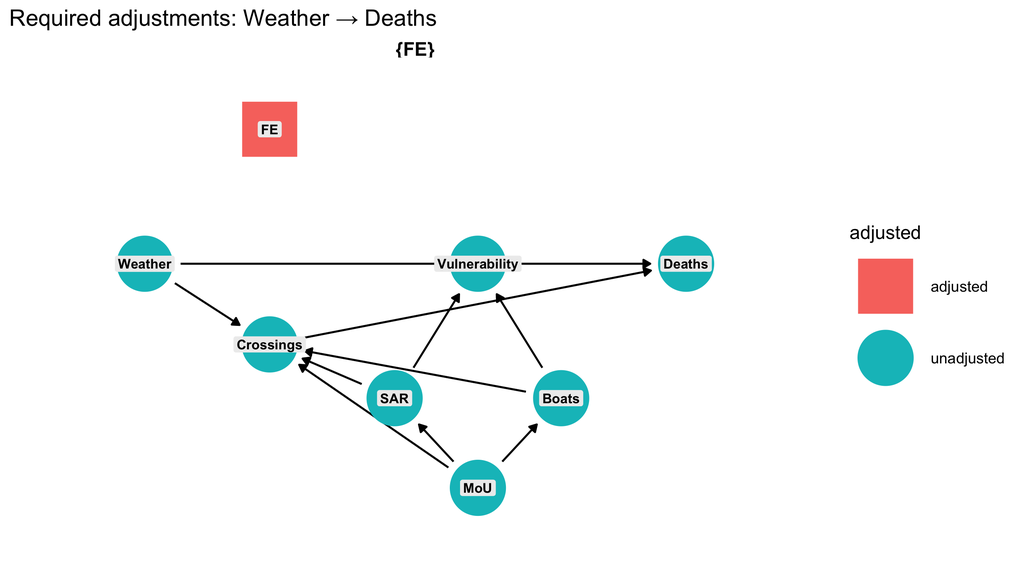

```r
ggdag_adjustment_set(dag, text = FALSE) +
  geom_label(aes(label = name),
             fill = "grey93", colour = "black",
             size = 3, fontface = "bold",
             label.padding = unit(0.2, "lines"),
             label.size = 0, na.rm = TRUE) +
  theme_dag() +
  ggtitle("Required adjustments: Weather → Deaths")
```

## 16. Summary

| Finding | Implication |
| --- | --- |
| **MoU → Deaths**: no backdoor paths | Total effect identified without conditioning (MoU is exogenous) |
| **Weather → Deaths**: one backdoor through FE | Conditioning on FE (month + grid FE) is **sufficient** |
| **Conditioning on Crossings** (= using rate) | Opens collider paths through SAR/Boats → **Kronmal bias** |
| **Vulnerability is latent** | Weather × Post interaction identifies MoU’s effect on the Weather → Vulnerability → Deaths pathway **without** observing Vulnerability |
| **Exclusion restriction** | No direct Weather × Post → Deaths path outside Vulnerability must hold |
| **Per-crossing decomposition infeasible** | Crossings only monthly + post-treatment → collider. Model A (event-level severity) is primary; monthly counts complementary |
| **Crossings ~ Weather × Post is valid** | {FE} sufficient; no collider because Crossings is outcome, not conditioning set. Diagnostic for volume channel |
| **Rate regression (Model D)** | $\beta_3$ partially protected by differencing, but collider bias changes across periods (SAR/Boats shift). Exploratory only |

### Data needs

| Variable | Status | Source |
| --- | --- | --- |
| Weather (SWH, wind, SST) | **Observed** | ERA5 |
| Deaths | **Observed** | IOM MMP |
| FE (date, grid) | **Observed** | Date/coordinates |
| SAR | Mostly unobserved (low quality data) | NGO fleet data |
| Boats | Partially observed | Frontex JORA |
| Crossings | Observed — **do not condition on** in primary model; use as **outcome** in diagnostic (Section 12); use as **denominator** only in exploratory Model D (Section 13) | IOM/UNHCR monthly |
| Vulnerability | **Unobserved** | No single data source |

### Potential missing edges

[output not shown]

### Literature support for DAG edges

[output not shown]

### Structural assumptions: literature support

[output not shown]

## References

1. Amenta, C., Di Betta, P., & Ferrara, C. (2021). The migrant crisis in the Mediterranean Sea: Empirical evidence on policy interventions. *Socio-Economic Planning Sciences*, 75, 100880.
2. Battiston, G. (2022). Rescue on stage: Border enforcement and public attention in the Mediterranean Sea. Marco Fanno Working Paper No. 0292.
3. Camarena, K. R., Claudy, S., Wang, Y., & Wright, A. L. (2020). Political and environmental risks influence migration and human smuggling across the Mediterranean Sea. *SSRN Working Paper*.
4. Cusumano, E., & Villa, M. (2019). Sea rescue NGOs: A pull factor of irregular migration? *EUI Policy Brief*.
5. Deiana, C., Maheshri, V., & Mastrobuoni, G. (2024). Migrants at sea: Unintended consequences of search and rescue operations. *American Economic Journal: Economic Policy*.
6. Elwert, F., & Winship, C. (2014). Endogenous selection bias: The problem of conditioning on a collider variable. *Annual Review of Sociology*, 40, 31–53.
7. Fasani, F., Frattini, T., & Weisser, R. (2019). The relationship between SAR operations and the probability of dying in the Central Mediterranean, 2012–2017. *Working Paper*.
8. Friebel, G., Manchin, M., Mendola, M., & Prarolo, G. (2024). International migration and illegal costs: Evidence from Africa-to-Europe smuggling routes. *Journal of International Economics*, 148, 103876.
9. Hoffmann Pham, K., & Komiyama, Y. (2024). Strategic choices of migrants and smugglers in the Central Mediterranean Sea. *Working Paper*.
10. Kronmal, R. A. (1993). Spurious correlation and the fallacy of the ratio standard revisited. *Journal of the Royal Statistical Society: Series A*, 156(3), 379–392.
11. Rodriguez Sanchez, A., Wucherpfennig, J., Rischke, R., & Iacus, S. M. (2023). Search-and-rescue in the Central Mediterranean Route does not induce migration: Predictive modeling to answer causal queries in migration research. *Scientific Reports*, 13, 12871.
12. Steinhilper, E., & Gruijters, R. J. (2018). A contested crisis: Policy narratives and empirical evidence on border deaths in the Mediterranean. *Sociology*, 52(3), 515–533.
13. Tafani, S., & Riccaboni, M. (2025). The impact of the EU–Turkey agreement on the number of lives lost at sea. *Humanities and Social Sciences Communications*, 12, 282.
14. Textor, J., van der Zander, B., Gilthorpe, M. S., Liskiewicz, M., & Ellison, G. T. (2016). Robust causal inference using directed acyclic graphs: The R package ‘dagitty’. *International Journal of Epidemiology*, 45(6), 1887–1894.
15. Zambiasi, D., & Albarosa, E. (2025). Externalizing rescue operations at sea: The migration deal between Italy and Libya. *Journal of Economic Geography*, 25(1), 41–58.